# US Voter ID_Nov21

This is an R Markdown document with the following analyses:

- Descriptive Statistics: top words/features
- Keyness Analysis: to identify which words are more frequently used by Republicans compared to Democrats.
- Target Keyword Analyses: to identify key words used when discussing voter ID specifically by both parties.
- Create a corpus of ID context: to use in Iramuteq in order to visualise word similarities

First we install the relevant libraries.

```r
library(readtext)
library(ggplot2)
library(quanteda)
require(quanteda)
require(quanteda.textmodels)
require(quanteda.textstats)
require(quanteda.textplots)
```

Then we load the data. We are loading data that has been pre-processed and lemmatised in Python. Words with a frequency less than 3 were also removed from the corpus.

```r
path_data <- system.file("C:/Users/analo/OneDrive - University of Glasgow/University of Glasgow/Thesis/CHAPTERS/DATA/Voter ID laws debates (US)/R Markdown", package = "readtext")

lemma <- readtext(paste0(path_data,"lemma.xlsx"), text_field = "freq")
```

Then we create the corpus and divide this in two for Democratic and Republican statements

```r
corpus <- corpus(lemma)
corp_dem <- corpus_subset(corpus, Party %in% c('Democratic'))
corp_rep<- corpus_subset(corpus, Party %in% c('Republican'))
```

We create a tokens object. tokens() segments texts in a corpus into tokens (words or sentences) by word boundaries. By default, tokens() only removes separators (typically whitespaces).

```r
tokens <- tokens(corpus)%>%
  tokens_compound(pattern = phrase(c('shelby county', 'north carolina', 'john lewis')))%>%
  tokens_select(pattern = c("madam","speaker", "mr"), selection = "remove")%>%
  tokens_replace(c("id"), c("identification"))%>%
  tokens_replace(c("vra"), c("voting_right_act"))%>%
  tokens_group(groups = Party) %>%
  tokens()
```

Then we create a dataframe

```r
dfm <- dfm(tokens)
```

#### Top words

We plot top features:

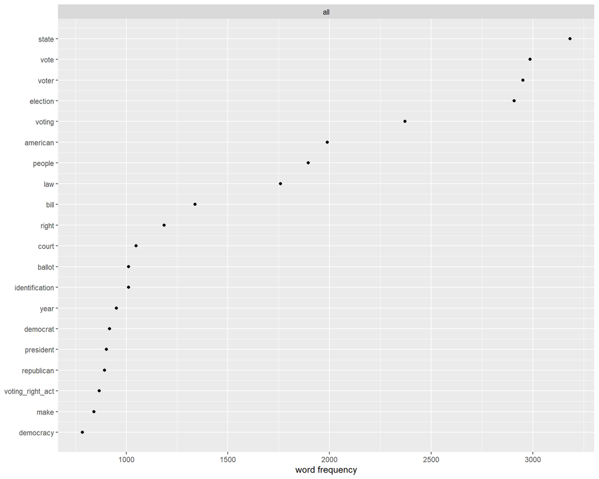

```r
freq <- textstat_frequency(dfm, n = 20)
ggplot(data = freq, aes(x = nrow(freq):1, y = frequency)) +
geom_point() +
facet_wrap(~ group, scales = "free") +
coord_flip() +
scale_x_continuous(breaks = nrow(freq):1,
labels = freq$feature) +
labs(x = NULL, y = "word frequency")
```

#### Keyness analysis

```r
# Calculate keyness
result_keyness <- textstat_keyness(dfm, target = 1L, measure = c("chi2"),sort = TRUE)
```

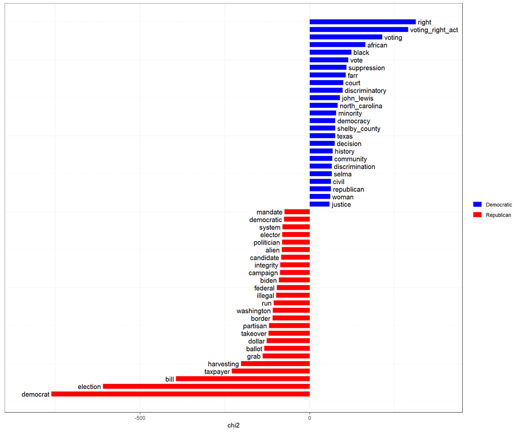

```r
# Plot estimated word keyness
textplot_keyness(result_keyness, labelsize = 4,labelcolor = "black", color = c("blue", "red"), min_count = 10, n = 25)
```

#### Target Keyword Analysis

To get a sense of how voter ID is specifically framed by both parties, I identified words connected to the key term “identification” based on their distance in the documents, by comparing frequency of words inside and outside of their contexts (20 words displayed around the target keyword, i.e. identification). Below are the top keywords for Republicans and Democrats. Contrasting the previous keyness analysis, this analysis does not compare words used by Republicans vs Democrats, but compares words used when discussing voter ID (nearby words), with words outside of this contextual window.

```r
id <- c("identification")
```

We create a tokens object for Republican and Democratic speaches

```r
## Republicans
tokens_rep <- tokens(corp_rep)%>%
  tokens_compound(pattern = phrase(c('shelby county', 'north carolina', 'john lewis', "voting right act")))%>%
  tokens_select(pattern = c("madam","speaker", "mr"), selection = "remove")%>%
  tokens_replace(c("id"), c("identification"))%>%
  tokens_replace(c("vra"), c("voting_right_act"))%>%
  tokens()

## Democrats
tokens_dem <- tokens(corp_dem)%>%
  tokens_compound(pattern = phrase(c('shelby county', 'north carolina', 'john lewis')))%>%
  tokens_select(pattern = c("madam","speaker", "mr"), selection = "remove")%>%
  tokens_replace(c("id"), c("identification"))%>%
  tokens_replace(c("vra"), c("voting_right_act"))%>%
  tokens()
```

We set a window surrounding our key term and compute words’ association with the keyword using textstat_keyness().

```r
## Republicans
toks_inside_rep <- tokens_keep(tokens_rep, pattern = id, window = 20)
toks_inside1_rep <- tokens_remove(tokens_rep, pattern = id) # remove the keywords
toks_outside_rep <- tokens_remove(tokens_rep, pattern = id, window = 20)

dfmat_inside_rep<- dfm(toks_inside_rep)
dfmat_outside_rep <- dfm(toks_outside_rep)

## Democrats
toks_inside_dem <- tokens_keep(tokens_dem, pattern = id, window = 20)
toks_inside1_dem <- tokens_remove(tokens_dem, pattern = id) # remove the keywords
toks_outside_dem <- tokens_remove(tokens_dem, pattern = id, window = 20)

dfmat_inside_dem<- dfm(toks_inside_dem)
dfmat_outside_dem <- dfm(toks_outside_dem)
```

Calculate keyness:

```r
# Republicans
tstat_key_inside_rep <- textstat_keyness(rbind(dfmat_inside_rep, dfmat_outside_rep),target = seq_len(ndoc(dfmat_inside_rep)))

# Democrats
tstat_key_inside_dem <- textstat_keyness(rbind(dfmat_inside_dem, dfmat_outside_dem),target = seq_len(ndoc(dfmat_inside_dem)))
```

Then we plot using the ggplot library:

```r
library(dplyr)
library(scales)
library(ggplot2)
library(gapminder)
```

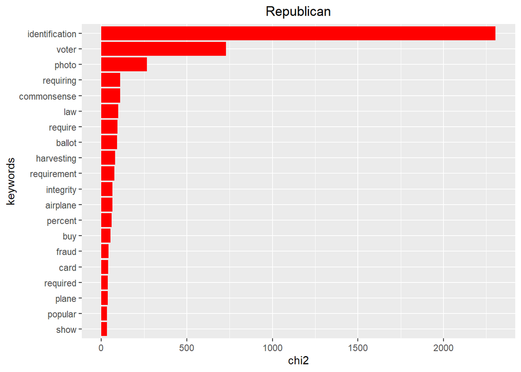

```r
target_rep <- tstat_key_inside_rep %>% slice_max(order_by = chi2, n = 20)
ggplot(data = target_rep, mapping = aes(x = reorder(feature, chi2), chi2)) +
  geom_bar(stat = "identity", fill="red") + coord_flip() + labs(x= "keywords", y= "chi2") + ggtitle("Republican") +
  theme(plot.title = element_text(hjust = 0.5))
```

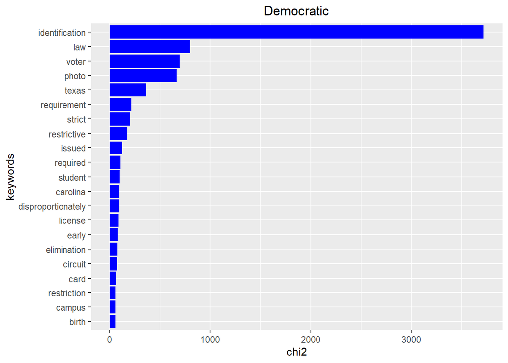

```r
target_dem <- tstat_key_inside_dem %>% slice_max(order_by = chi2, n = 20)
ggplot(data = target_dem, mapping = aes(x = reorder(feature, chi2), chi2)) +
  geom_bar(stat = "identity", fill="blue") + coord_flip() + labs(x= "keywords", y= "chi2")+ ggtitle("Democratic") +
  theme(plot.title = element_text(hjust = 0.5))
```

#### Preparing data to visualise in Iramuteq

```r
id_dem <- kwic(
  tokens_dem,
  pattern= c( "identification"),
  window = 20,
  valuetype = c("glob", "regex", "fixed"),
)

id_rep <- kwic(
  tokens_dem,
  pattern= c( "identification"),
  window = 20,
  valuetype = c("glob", "regex", "fixed"),
)
```

Then I combine these two datasets and export it. To visualise this in iramuteq, Democratic and Republican texts are copied into separate .txt files and loaded into the software.

```r
library(dplyr)
# Join pre and post keyword into a text column
id_dem$text <- paste(id_dem$pre, id_dem$keyword, id_dem$post)
id_rep$text <- paste(id_rep$pre, id_rep$keyword, id_rep$post)

# Assign column for each party
id_dem$Party <- "Democratic"
id_rep$Party <- "Republican"

# Join two datasets together
id <- rbind(id_dem, id_rep)

# Export
write.csv(id, "id.csv")
```